# Laporan Hasil Pengawasan Kemasan Tahun 2021-2023

Zaky Nur Kusmantoro

2024-01-20

# Perhitungan Migrasi

Pertama, akan dilihat dulu jumlah data **migrasi** berdasarkan waktunya (Semester 2 Tahun 2021 - Semester 1 Tahun 2023) dan dikelompokkan berdasarkan batasnya yaitu 1 untuk `(x < 0,05)`, 2 untuk `(0,05 ≤ x< 0,6)`, dan 3 untuk `(x ≥ 0,6)`

## Tabel Perhitungan Jumlah untuk Setiap Batas dalam Semester

| semester | N | x < 0,05 | 0,05 ≤ x< 0,6 | x ≥ 0,6 |
| --- | --- | --- | --- | --- |
| 2021-01 | 82 | 57 | 24 | 1 |
| 2022-01 | 292 | 150 | 134 | 8 |
| 2022-02 | 230 | 103 | 110 | 17 |
| 2023-01 | 139 | 61 | 75 | 3 |

## Tabel Perhitungan Persentase untuk Setiap Batas dalam Semester

| semester | N | x < 0,05 | 0,05 ≤ x< 0,6 | x ≥ 0,6 |
| --- | --- | --- | --- | --- |
| 2021-01 | 82 | 69.51 | 29.27 | 1.22 |
| 2022-01 | 292 | 51.37 | 45.89 | 2.74 |
| 2022-02 | 230 | 44.78 | 47.83 | 7.39 |
| 2023-01 | 139 | 43.88 | 53.96 | 2.16 |

Selanjutnya, pembagian terhadap **Sarana Produksi** dan **Sarana Distribusi** untuk setiap semester

## Tabel Perhitungan Jumlah untuk Setiap Batas dan Lokasi Sampling dalam Semester

| semester | lokasi_sampling | N | x < 0,05 | 0,05 ≤ x< 0,6 | x ≥ 0,6 |
| --- | --- | --- | --- | --- | --- |
| 2021-01 | Sarana Distribusi | 32 | 22 | 9 | 1 |
| 2021-01 | Sarana Produksi | 50 | 35 | 15 | NA |
| 2022-01 | Sarana Distribusi | 232 | 109 | 115 | 8 |
| 2022-01 | Sarana Produksi | 60 | 41 | 19 | NA |
| 2022-02 | Sarana Distribusi | 153 | 68 | 78 | 7 |
| 2022-02 | Sarana Produksi | 77 | 35 | 32 | 10 |
| 2023-01 | Sarana Distribusi | 103 | 44 | 57 | 2 |
| 2023-01 | Sarana Produksi | 36 | 17 | 18 | 1 |

## Tabel Persentase Jumlah untuk Setiap Batas dan Lokasi Sampling dalam Semester

| semester | lokasi_sampling | N | x < 0,05 | 0,05 ≤ x< 0,6 | x ≥ 0,6 |
| --- | --- | --- | --- | --- | --- |
| 2021-01 | Sarana Distribusi | 32 | 68.75 | 28.12 | 3.12 |
| 2021-01 | Sarana Produksi | 50 | 70 | 30 | NA |
| 2022-01 | Sarana Distribusi | 232 | 46.98 | 49.57 | 3.45 |
| 2022-01 | Sarana Produksi | 60 | 68.33 | 31.67 | NA |
| 2022-02 | Sarana Distribusi | 153 | 44.44 | 50.98 | 4.58 |
| 2022-02 | Sarana Produksi | 77 | 45.45 | 41.56 | 12.99 |
| 2023-01 | Sarana Distribusi | 103 | 42.72 | 55.34 | 1.94 |
| 2023-01 | Sarana Produksi | 36 | 47.22 | 50 | 2.78 |

## Persebaran Nilai Migrasi untuk setiap Semester dan Lokasi Sampling

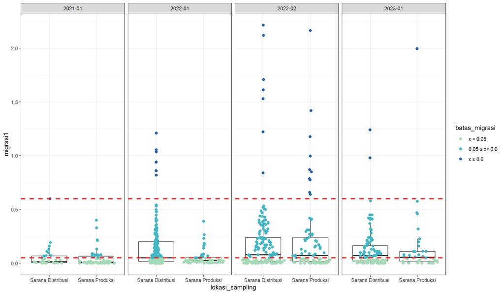

Grafik `boxplot` berfungsi untuk memetakan distribusi data, kemudian digambarkan plot untuk setiap data untuk melihat ada berapa titik yang lebih dari batas `x ≥ 0,6` dan diantara 0,05 dan 0,6 `0,05 ≤ x< 0,6`. Garis merah tersebut menandakan batas-batas dari yang ditentukan yaitu 0,6 (yang di bagian atas) dan 0,05 (yang di bagian bawah).

## Peta Persebaran Migrasi dari Lokasi Sampling Semester 2 2021 hingga Semester 1 2023

Selanjutnya, akan dilihat persebaran titik berdasarkan lokasinya dengan ditandai lokasi yang memiliki nilai migrasi ≥ 0,6

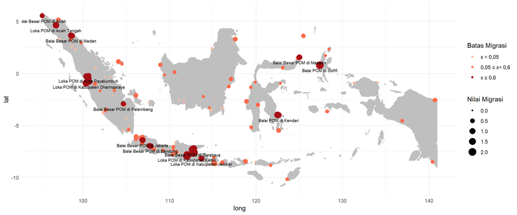

|  | semester | lokasi_sampling | balai | provinsi | migrasi1 |
| --- | --- | --- | --- | --- | --- |
| 1 | 2021-01 | Sarana Distribusi | Balai Besar POM di Aceh | Aceh | 0.6 |
| 2 | 2022-02 | Sarana Produksi | Balai Besar POM di Bandung | Jawa Barat | 0.64 |
| 3 | 2022-02 | Sarana Produksi | Balai Besar POM di Palembang | Sumatera Selatan | 0.66 |
| 4 | 2022-02 | Sarana Produksi | Balai Besar POM di Bandung | Jawa Barat | 0.775 |
| 5 | 2022-02 | Sarana Produksi | Loka POM di Kota Payakumbuh | Sumatera Barat | 0.788 |
| 6 | 2022-01 | Sarana Distribusi | Balai Besar POM Bandung | Jawa Barat | 0.82 |
| 7 | 2022-02 | Sarana Distribusi | Loka POM di Kabupaten Jember | Jawa Timur | 0.84 |
| 8 | 2022-02 | Sarana Produksi | Balai Besar POM di Surabaya | Jawa Timur | 0.85 |
| 9 | 2022-01 | Sarana Distribusi | Balai Besar POM di Manado | Sulawesi Utara | 0.86 |
| 10 | 2022-01 | Sarana Distribusi | Balai Besar POM Bandung | Jawa Barat | 0.86 |

[output cut: 19 more lines]

# Perhitungan Kadar Cemaran

Selanjutnya, akan dilihat dulu jumlah data **cemaran** berdasarkan waktunya (Semester 2 Tahun 2021 - Semester 1 Tahun 2023) dan dikelompokkan berdasarkan batasnya yaitu 1 untuk `(x < 0,01)`, 2 untuk `(x ≥ 0,01)`

## Tabel Perhitungan Jumlah untuk Setiap Batas dalam Semester

| semester | N | x < 0,01 | x ≥ 0,01 |
| --- | --- | --- | --- |
| 2021-01 | 46 | 41 | 5 |
| 2022-01 | 245 | 235 | 10 |
| 2022-02 | 227 | 226 | 1 |
| 2023-01 | 134 | 127 | 7 |

## Tabel Perhitungan Persentase untuk Setiap Batas dalam Semester

| semester | N | x < 0,01 | x ≥ 0,01 |
| --- | --- | --- | --- |
| 2021-01 | 46 | 89.13 | 10.87 |
| 2022-01 | 245 | 95.92 | 4.08 |
| 2022-02 | 227 | 99.56 | 0.44 |
| 2023-01 | 134 | 94.78 | 5.22 |

Selanjutnya, pembagian terhadap **Sarana Produksi** dan **Sarana Distribusi** untuk setiap semester

## Tabel Perhitungan Jumlah untuk Setiap Batas dan Lokasi Sampling dalam Semester

| semester | lokasi_sampling | N | x < 0,01 | x ≥ 0,01 |
| --- | --- | --- | --- | --- |
| 2021-01 | Sarana Distribusi | 26 | 22 | 4 |
| 2021-01 | Sarana Produksi | 20 | 19 | 1 |
| 2022-01 | Sarana Distribusi | 227 | 218 | 9 |
| 2022-01 | Sarana Produksi | 18 | 17 | 1 |
| 2022-02 | Sarana Distribusi | 153 | 152 | 1 |
| 2022-02 | Sarana Produksi | 74 | 74 | NA |
| 2023-01 | Sarana Distribusi | 101 | 94 | 7 |
| 2023-01 | Sarana Produksi | 33 | 33 | NA |

## Tabel Persentase Jumlah untuk Setiap Batas dan Lokasi Sampling dalam Semester

| semester | lokasi_sampling | N | x < 0,01 | x ≥ 0,01 |
| --- | --- | --- | --- | --- |
| 2021-01 | Sarana Distribusi | 26 | 84.62 | 15.38 |
| 2021-01 | Sarana Produksi | 20 | 95 | 5 |
| 2022-01 | Sarana Distribusi | 227 | 96.04 | 3.96 |
| 2022-01 | Sarana Produksi | 18 | 94.44 | 5.56 |
| 2022-02 | Sarana Distribusi | 153 | 99.35 | 0.65 |
| 2022-02 | Sarana Produksi | 74 | 100 | NA |
| 2023-01 | Sarana Distribusi | 101 | 93.07 | 6.93 |
| 2023-01 | Sarana Produksi | 33 | 100 | NA |

## Persebaran Nilai Cemaran untuk setiap Semester dan Lokasi Sampling

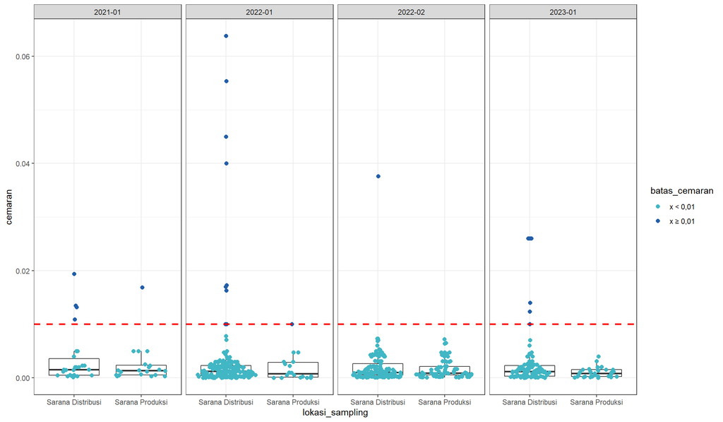

## Peta Persebaran Cemaran dari Lokasi Sampling Semester 2 2021 hingga Semester 1 2023

Selanjutnya, akan dilihat persebaran titik berdasarkan lokasinya dengan ditandai lokasi yang memiliki nilai cemaran ≥ 0,01

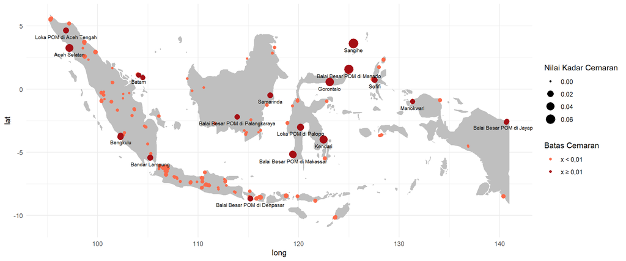

|  | semester | lokasi_sampling | balai | provinsi | cemaran |
| --- | --- | --- | --- | --- | --- |
| 1 | 2022-01 | Sarana Produksi | Manokwari | Papua Barat | 0.01 |
| 2 | 2022-01 | Sarana Distribusi | Batam | Kep. Riau | 0.01 |
| 3 | 2022-01 | Sarana Distribusi | Kota Tanjungpinang | Kep. Riau | 0.01 |
| 4 | 2023-01 | Sarana Distribusi | Balai Besar POM di Jayapura | Papua | 0.01 |
| 5 | 2021-01 | Sarana Distribusi | Jayapura | Papua | 0.0109 |
| 6 | 2023-01 | Sarana Distribusi | Balai Besar POM di Palangkaraya | Kalimantan Tengah | 0.01238 |
| 7 | 2021-01 | Sarana Distribusi | Gorontalo | Gorontalo | 0.01315 |
| 8 | 2021-01 | Sarana Distribusi | Samarinda | Kalimantan Timur | 0.0135 |
| 9 | 2023-01 | Sarana Distribusi | Balai Besar POM di Denpasar | Bali | 0.014 |
| 10 | 2022-01 | Sarana Distribusi | Loka POM di Aceh Tengah | Aceh | 0.0163 |

[output cut: 13 more lines]